# Section 3 Assignment

**Question 1:** Why do the logistic, log, and identity link functions enable us to interpret coefficient as a log-odds ratios, log-risk ratios, and risk differences? Please show the math.

Log Odds Ratio -
General Form:
$$\log[\frac
{P(Y=1|X)}{1−𝑃(𝑌=1|𝑋)}]=\beta_0 + \beta_1 X$$
When X=1
$$\log[(\frac {P(Y=1|X=1)}{1−𝑃(𝑌=1|𝑋=1)}]=\beta_0 +
\beta_1*1 = \beta_0 + \beta_1$$
When X=0
$$\log[\frac {P(Y=1|X=0)}{1−𝑃(𝑌=1|𝑋=0)}]=\beta_0 +
\beta_1*0= \beta_0$$
$$\log[\frac
{\frac {P(Y=1|X=1)}{1−𝑃(𝑌=1|𝑋=1)}} {\frac {P(Y=1|X=0)}{1−𝑃(𝑌=1|𝑋=0)}}] =
\beta_0 + \beta_1 - \beta_0 = \beta_1$$

Log risk difference -
General Form:
$$\log[{P(Y=1|X)}]=\beta_0 +
\beta_1X$$
When X=1
$$\log[{P(Y=1|X=1)}]=\beta_0 + \beta_1*1=\beta_0 +
\beta_1$$
When X=0
$$\log[{P(Y=1|X=0)}]=\beta_0 +
\beta_1*0=\beta_0$$
$$\log[{P(Y=1|X=1)}]-(1-\log[{P(Y=1|X=0)}]) = \beta_0 + \beta_1 - \beta_0
= \beta_1$$

**Question 2)** Using the NHEFS dataset (available on CANVAS), please plot the unadjusted dose-response relation between smoking intensity and the *risk* of high blood pressure.

```
## # A tibble: 2,000 × 8
##    qsmk high_BP smokeintensity   sex   age  race school marital
##   <dbl>   <dbl>          <dbl> <dbl> <dbl> <dbl>  <dbl>   <dbl>
## 1     0       0             20     0    33     0      8       2
## 2     0       0             10     1    36     0     12       2
## 3     0       0             17     1    29     0     10       2
## 4     0       0             40     0    34     0     12       2
## 5     0       0             20     1    45     0      8       2
## # … with 1,995 more rows
```

```
##
##    0    1
## 1522  478
```

```
##
##   1   2   3   4   5   6   7   8   9  10  11  12  13  14  15  16  17  18  19  20
##  31  51  34  34  75  21  17  23   4 220   3  35   6   8 127  10   6  11   1 739
##  22  24  25  28  30  32  35  40  45  46  50  55  60  80
##   1   1  37   2 227   1  12 212   7   1  32   1   8   2
```

```
##
## Call:
## glm(formula = high_BP ~ bs(smokeintensity, df = 3, degree = 3),
##     family = binomial(link = "logit"), data = nhefs)
##
## Deviance Residuals:
##     Min       1Q   Median       3Q      Max
## -1.4177  -0.7466  -0.7374  -0.6641   1.8001
##
## Coefficients:
##                                         Estimate Std. Error z value Pr(>|z|)
## (Intercept)                              -1.3996     0.1826  -7.663 1.81e-14
## bs(smokeintensity, df = 3, degree = 3)1   0.7458     0.6321   1.180    0.238
## bs(smokeintensity, df = 3, degree = 3)2  -0.5537     0.8345  -0.663    0.507
## bs(smokeintensity, df = 3, degree = 3)3   1.9488     1.3318   1.463    0.143
##
## (Intercept)                             ***
## bs(smokeintensity, df = 3, degree = 3)1
## bs(smokeintensity, df = 3, degree = 3)2
## bs(smokeintensity, df = 3, degree = 3)3
## ---
## Signif. codes:  0 '***' 0.001 '**' 0.01 '*' 0.05 '.' 0.1 ' ' 1
##
## (Dispersion parameter for binomial family taken to be 1)
##
##     Null deviance: 2199.7  on 1999  degrees of freedom
## Residual deviance: 2195.8  on 1996  degrees of freedom
## AIC: 2203.8
##
## Number of Fisher Scoring iterations: 4
```

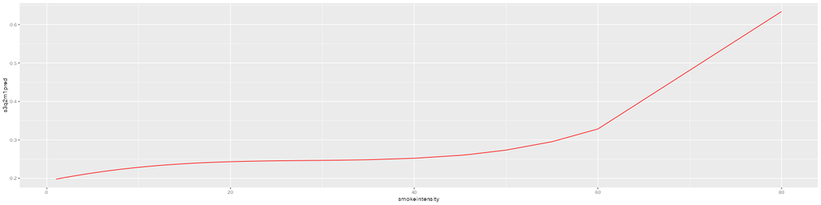

```
##
##    2    3    4    5
## 1584  102  130  184
```

```
##
##   1   2   3   4   5   6   7   8   9  10  11  12  13  14  15  16  17  18  19  20
##  31  51  34  34  75  21  17  23   4 220   3  35   6   8 127  10   6  11   1 739
##  22  24  25  28  30  32  35  40  45  46  50  55  60  80
##   1   1  37   2 227   1  12 212   7   1  32   1   8   2
```

#Conditional Portion

```
## [1] 0.118922
```

```
##
## Call:
## glm(formula = high_BP ~ .^2, data = nhefs)
##
## Deviance Residuals:
##     Min       1Q   Median       3Q      Max
## -0.7056  -0.2509  -0.1687  -0.0050   0.9893
##
## Coefficients:
##                             Estimate Std. Error t value Pr(>|t|)
## (Intercept)               -2.027e-01  1.987e+00  -0.102 0.918769
## qsmk                       3.555e-01  6.046e-01   0.588 0.556643
## smokeintensity             8.289e-03  1.467e-02   0.565 0.572158
## sex                        2.130e+00  6.560e-01   3.247 0.001188 **
## age                        1.282e-02  2.493e-02   0.514 0.607208
## race                      -1.972e+00  1.501e+00  -1.314 0.189107
## school                     7.871e-02  1.057e-01   0.745 0.456426
## marital                   -1.015e+00  3.475e-01  -2.921 0.003527 **
## s3q2m1pred                 1.485e+00  9.048e+00   0.164 0.869604
## qsmk:smokeintensity        7.150e-03  4.097e-03   1.745 0.081104 .
## qsmk:sex                   1.148e-01  4.911e-02   2.337 0.019525 *
## qsmk:age                  -1.701e-03  1.946e-03  -0.874 0.382144
## qsmk:race                  2.521e-01  9.701e-02   2.598 0.009435 **
## qsmk:school                3.090e-03  8.020e-03   0.385 0.700047
## qsmk:marital              -2.405e-02  2.940e-02  -0.818 0.413535
## qsmk:s3q2m1pred           -2.465e+00  2.709e+00  -0.910 0.362848
## smokeintensity:sex         1.220e-02  3.786e-03   3.222 0.001292 **
## smokeintensity:age         9.510e-06  1.546e-04   0.061 0.950970
## smokeintensity:race       -2.855e-03  1.312e-02  -0.218 0.827786
## smokeintensity:school      2.105e-04  6.511e-04   0.323 0.746528
## smokeintensity:marital    -7.452e-03  2.165e-03  -3.442 0.000591 ***
## smokeintensity:s3q2m1pred -2.423e-03  2.712e-02  -0.089 0.928803
## sex:age                   -1.625e-03  1.709e-03  -0.951 0.341572
## sex:race                   1.383e-01  6.429e-02   2.151 0.031577 *
## sex:school                 2.951e-03  6.932e-03   0.426 0.670400
## sex:marital               -5.071e-02  2.094e-02  -2.422 0.015533 *
## sex:s3q2m1pred            -9.756e+00  2.962e+00  -3.294 0.001005 **
## age:race                   8.103e-03  3.078e-03   2.632 0.008548 **
## age:school                 1.385e-04  2.758e-04   0.502 0.615519
## age:marital               -7.461e-04  9.098e-04  -0.820 0.412268
## age:s3q2m1pred            -3.021e-02  1.137e-01  -0.266 0.790437
## race:school               -8.627e-04  1.046e-02  -0.082 0.934282
## race:marital               2.716e-02  2.689e-02   1.010 0.312584
## race:s3q2m1pred            6.829e+00  7.162e+00   0.954 0.340419
## school:marital             8.068e-03  3.564e-03   2.264 0.023694 *
## school:s3q2m1pred         -5.011e-01  4.775e-01  -1.049 0.294169
## marital:s3q2m1pred         4.824e+00  1.570e+00   3.072 0.002154 **
## ---
## Signif. codes:  0 '***' 0.001 '**' 0.01 '*' 0.05 '.' 0.1 ' ' 1
##
## (Dispersion parameter for gaussian family taken to be 0.1687113)
##
##     Null deviance: 363.76  on 1999  degrees of freedom
## Residual deviance: 331.18  on 1963  degrees of freedom
## AIC: 2155.3
##
## Number of Fisher Scoring iterations: 2
```

**Question 5:** Using the NHEFS data and a propensity score model with IP weighting, estimate the marginally adjusted risk ratio and risk difference for the association between quitting smoking and high blood pressure. Adjust for smokeintensity, sex, age, race, school, and marital status. Please use appropriate coding for all variables, but do not adjust for interaction effects. As always, use appropriate standard error estimators.

```
##    Min. 1st Qu.  Median    Mean 3rd Qu.    Max.
##  0.3086  0.8807  0.9573  0.9966  1.0646  2.9879
```

```r
q5mrd <- glm(high_BP ~ qsmk, data = nhefs, weights = sw, family = quasibinomial("identity"))
coeftest(q5mrd, vcov. = vcovHC)
```

```
##
## z test of coefficients:
##
##              Estimate Std. Error z value  Pr(>|z|)
## (Intercept)  0.270554   0.011592 23.3398 < 2.2e-16 ***
## qsmk        -0.114543   0.022275 -5.1421 2.716e-07 ***
## ---
## Signif. codes:  0 '***' 0.001 '**' 0.01 '*' 0.05 '.' 0.1 ' ' 1
```

```r
q5mrr <- glm(high_BP ~ qsmk, data = nhefs, weights = sw, family = poisson("log"))
coeftest(q5mrr, vcov. = vcovHC)
```

```
##
## z test of coefficients:
##
##              Estimate Std. Error  z value  Pr(>|z|)
## (Intercept) -1.307285   0.042845 -30.5118 < 2.2e-16 ***
## qsmk        -0.550544   0.129233  -4.2601 2.044e-05 ***
## ---
## Signif. codes:  0 '***' 0.001 '**' 0.01 '*' 0.05 '.' 0.1 ' ' 1
```

**Question 6:** Is the positivity assumption met for the propensity score model fit in Question 5? Is the positivity assumption required to interpret the estimate in Question 5 AND Question 3 as a causal contrast of potential outcomes? Why?

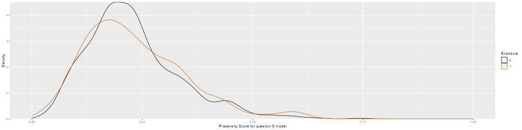

When looking at the graph, positivity is not violated for question 6 model. This is because the mass of density for the exposed (orange) occurs in essentially the same place as the density mass for the unexposed (black).

```
##    Min. 1st Qu.  Median    Mean 3rd Qu.    Max.
##   0.239   1.052   1.165   1.007   1.255   3.207
```

Min. 1st Qu. Median Mean 3rd Qu. Max.

0.5214 0.8209 0.9507 1.0003 1.1231 2.7366

The mean of the stabilized weights is essentially 1. The max weight is not large relative to the mean and min. This suggests that the weights are “well-behaved.” Thus, in this particular case, we are not concerned with violations of the positivity assumption.

Positivity assumption is required to interpret the estimate in Question 3 and 5 because we are using the average treatment effect. We need to ensure that there are exposed and unexposed individuals on all levels in order to ensure that the positivity assumption is not violated.